# R Notebook

# Make figures for ESA 2024 presentation

```r
knitr::opts_chunk$set(echo = FALSE,warning = FALSE,message = FALSE)
### make prez figures
require(tidyverse)
require(ggplot2)
require(lubridate)
require(scales)
require(viridis)
require(ggeffects)
require(ggimage)
require(magick)
require(cowplot)
require(ggggeffects)
require(emmeans)
require(multcomp)
wmean <- read_rds("../data/wmean.rds")

g <- read_rds("../data/growth.rds") %>%
  filter(!is.na(gweight),!is.infinite(gweight),!is.infinite(meanmaxtempI),
         !is.infinite(meanmaxtempO))
```

## Question 1: How do heat waves affect nestling birds across land cover types?

### Hypothesis 1: forest is coolest, then orchard, grassland, row crop

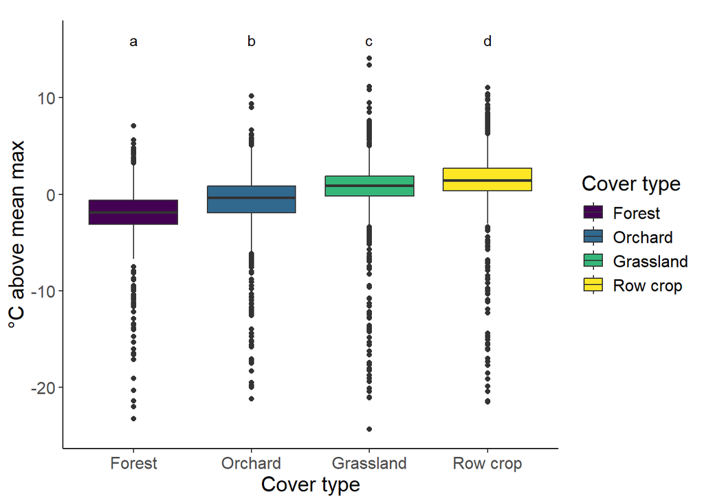

```
##   Tukey multiple comparisons of means
##     95% family-wise confidence level
##
## Fit: aov(formula = resid ~ habitat, data = filter(wmean, logger_position == "O"))
##
## $habitat
##                         diff       lwr       upr p adj
## Orchard-Forest     1.2619559 1.0994510 1.4244609     0
## Grassland-Forest   2.6088735 2.4521625 2.7655844     0
## Row crop-Forest    3.3670748 3.2113005 3.5228490     0
## Grassland-Orchard  1.3469176 1.1925161 1.5013190     0
## Row crop-Orchard   2.1051188 1.9516682 2.2585694     0
## Row crop-Grassland 0.7582013 0.6109004 0.9055022     0
```

### Hypothesis 2: Nestling growth declines with temperature

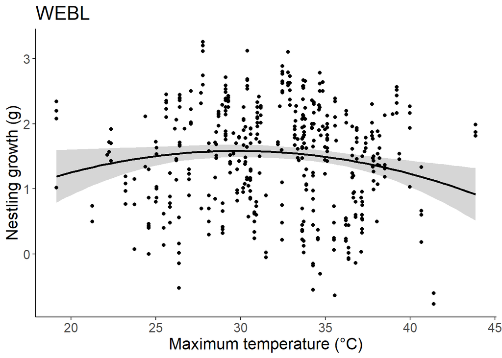

```
##
## Call:
## lm(formula = gweight ~ meanmaxtempI + I(meanmaxtempI^2), data = g %>%
##     filter(Species == "WEBL"))
##
## Residuals:
##     Min      1Q  Median      3Q     Max
## -2.1063 -0.5998  0.1272  0.6256  1.6880
##
## Coefficients:
##                    Estimate Std. Error t value Pr(>|t|)
## (Intercept)       -1.441617   1.314467  -1.097   0.2734
## meanmaxtempI       0.202720   0.084296   2.405   0.0166 *
## I(meanmaxtempI^2) -0.003396   0.001336  -2.542   0.0114 *
## ---
## Signif. codes:  0 '***' 0.001 '**' 0.01 '*' 0.05 '.' 0.1 ' ' 1
##
## Residual standard error: 0.7917 on 435 degrees of freedom
##   (26 observations deleted due to missingness)
## Multiple R-squared:  0.01842,    Adjusted R-squared:  0.01391
## F-statistic: 4.082 on 2 and 435 DF,  p-value: 0.01752
```

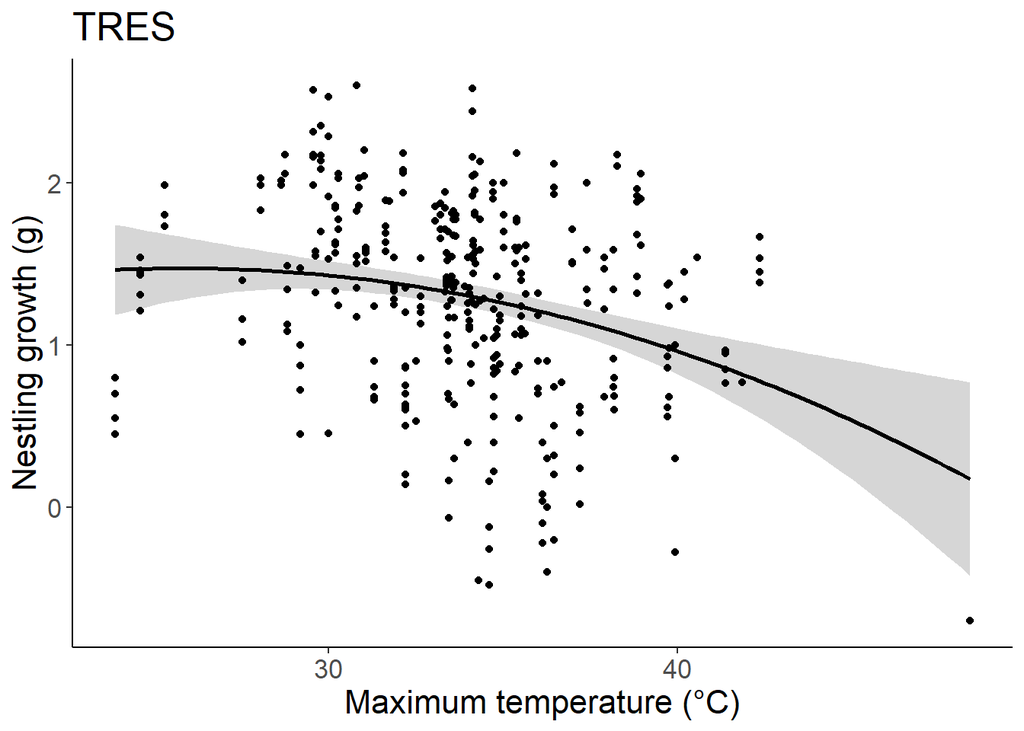

```
##
## Call:
## lm(formula = gweight ~ meanmaxtempI + I(meanmaxtempI^2), data = g %>%
##     filter(Species == "TRES"))
##
## Residuals:
##     Min      1Q  Median      3Q     Max
## -1.7224 -0.3697  0.0749  0.4266  1.3223
##
## Coefficients:
##                     Estimate Std. Error t value Pr(>|t|)
## (Intercept)        3.5490342  0.9169813   3.870  0.00013 ***
## meanmaxtempI      -0.1024460  0.0496663  -2.063  0.03988 *
## I(meanmaxtempI^2)  0.0010342  0.0006699   1.544  0.12354
## ---
## Signif. codes:  0 '***' 0.001 '**' 0.01 '*' 0.05 '.' 0.1 ' ' 1
##
## Residual standard error: 0.5917 on 350 degrees of freedom
##   (28 observations deleted due to missingness)
## Multiple R-squared:  0.04451,    Adjusted R-squared:  0.03905
## F-statistic: 8.151 on 2 and 350 DF,  p-value: 0.0003467
```

## Question 2: How does the effect of heat on growth vary across land cover types?

### Hypothesis 1: Forest and orchard have relatively more canopy cover than grassland and row crop

Should use canopy cover instead of wmean, or filter wmean down to unique combos of year & cc & box

```
##   Tukey multiple comparisons of means
##     95% family-wise confidence level
##
## Fit: aov(formula = canopy_cover ~ habitat, data = unique_canopy_measures, conf.level = 0.95)
##
## $habitat
##                         diff       lwr         upr     p adj
## Orchard-Forest     -13.18576 -26.10802  -0.2635098 0.0435601
## Grassland-Forest   -59.49844 -71.37742 -47.6194602 0.0000000
## Row crop-Forest    -63.02684 -75.49977 -50.5539114 0.0000000
## Grassland-Orchard  -46.31268 -58.02312 -34.6022400 0.0000000
## Row crop-Orchard   -49.84108 -62.15360 -37.5285581 0.0000000
## Row crop-Grassland  -3.52840 -14.74106   7.6842609 0.8470921
```

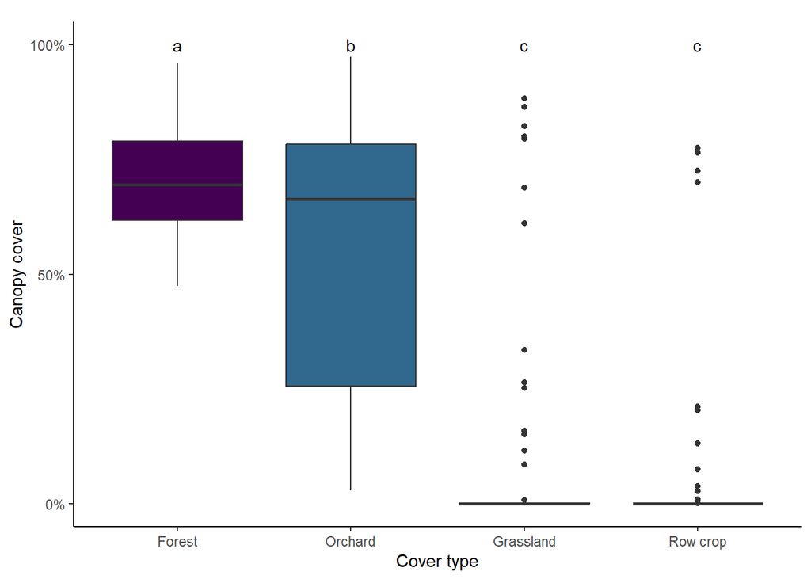

### Hypothesis 2: Internal nest box temp decreases with increasing canopy cover

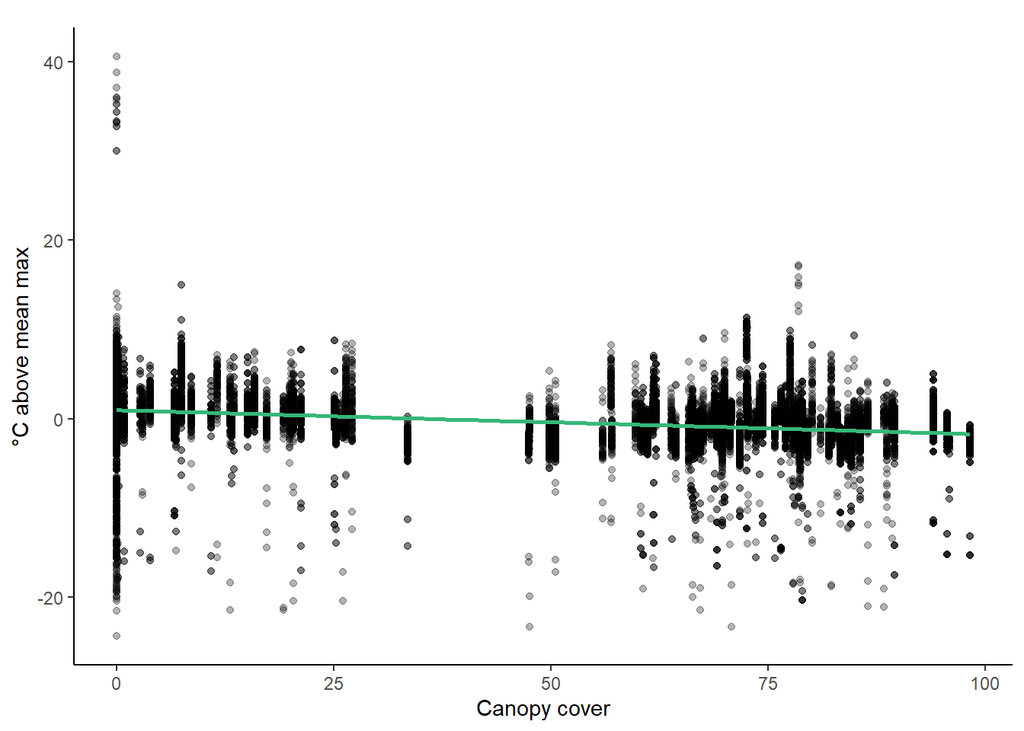

```
##
## Call:
## lm(formula = resid ~ canopy_cover, data = wmean)
##
## Residuals:
##     Min      1Q  Median      3Q     Max
## -25.337  -1.317  -0.042   1.340  39.615
##
## Coefficients:
##                Estimate Std. Error t value Pr(>|t|)
## (Intercept)   0.9922093  0.0229550   43.22   <2e-16 ***
## canopy_cover -0.0271343  0.0004651  -58.34   <2e-16 ***
## ---
## Signif. codes:  0 '***' 0.001 '**' 0.01 '*' 0.05 '.' 0.1 ' ' 1
##
## Residual standard error: 2.924 on 30194 degrees of freedom
##   (1303 observations deleted due to missingness)
## Multiple R-squared:  0.1013, Adjusted R-squared:  0.1013
## F-statistic:  3403 on 1 and 30194 DF,  p-value: < 2.2e-16
```

### Hypothesis 3: Agriculture makes nestlings more vulnerable to the negative effects of heat. Prediction: After accounting for the direct effects of heat, heat will still cause growth to decline more in agricultural land uses compared to natural land uses (i.e. there will still be an interactive effect of heat and land cover)

For explanation of why this model is best, check code/danny_meeting_20240213.html

## WEBL

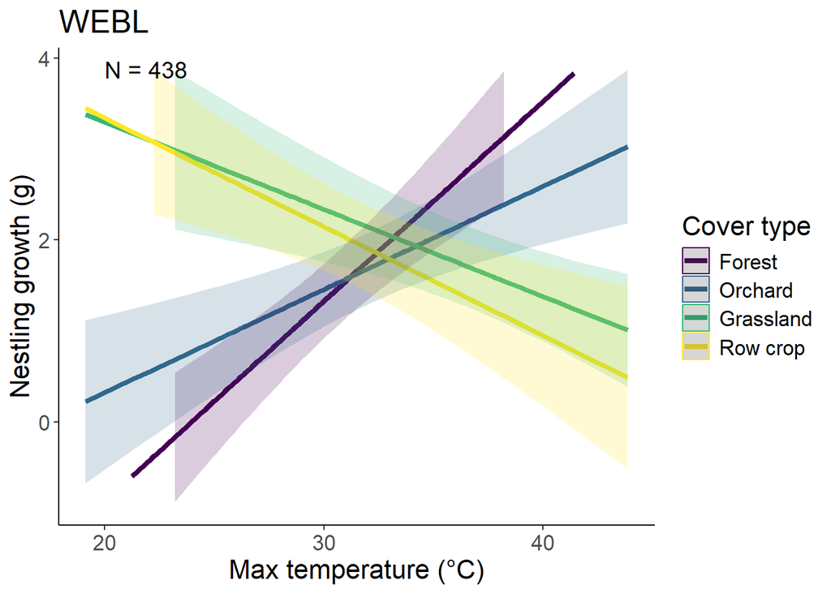

[figure not shown]

[figure not shown]

## TRES

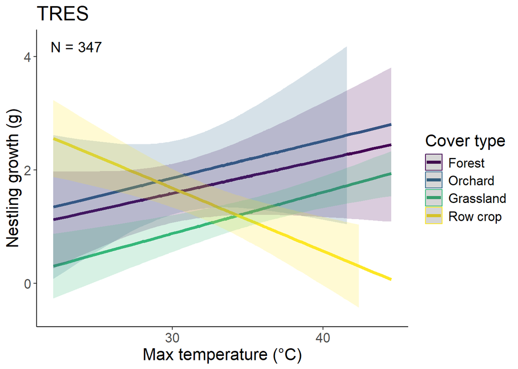

[figure not shown]

[figure not shown]

[figure not shown]

## Question 3: Why is nestling growth disproportionately low under extreme heat in row crop?

### Hypothesis 1: Canopy cover availability reduces costs of behavioral thermoregulation

## WEBL

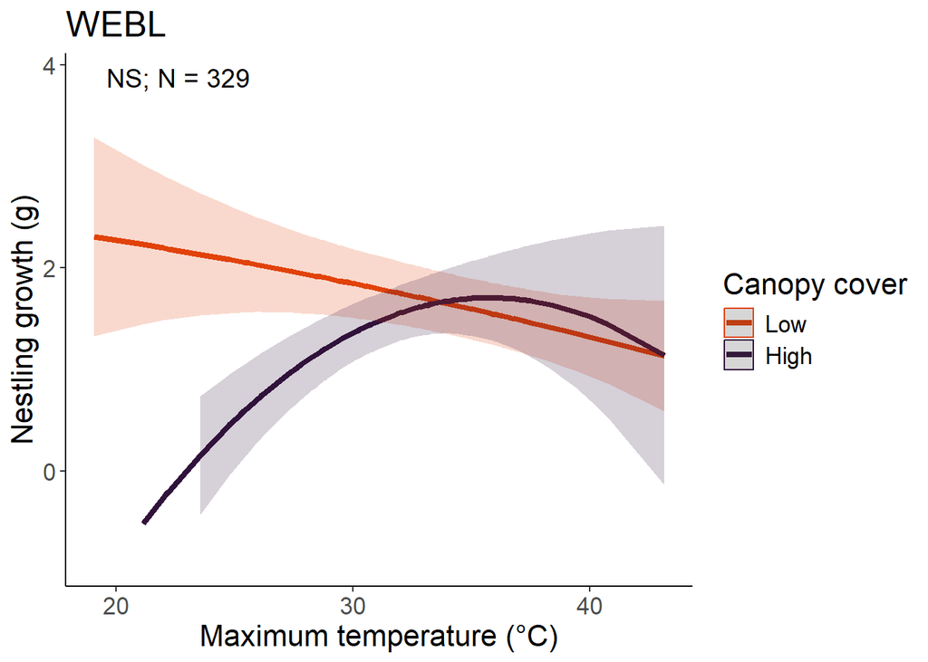

[figure not shown]

## TRES

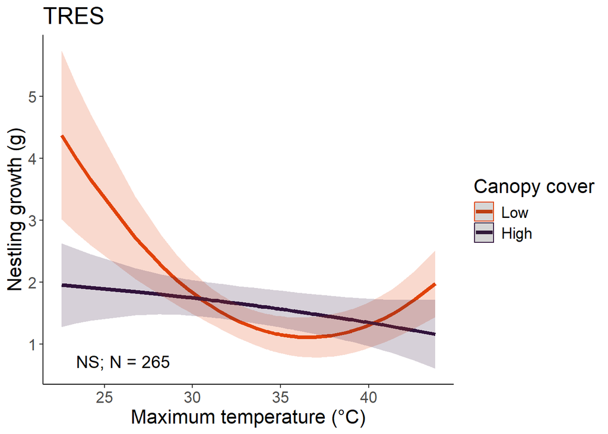

[figure not shown]

### Hypothesis 2: Irrigation supplements dietary water and facilitates evaporative cooling

## WEBL

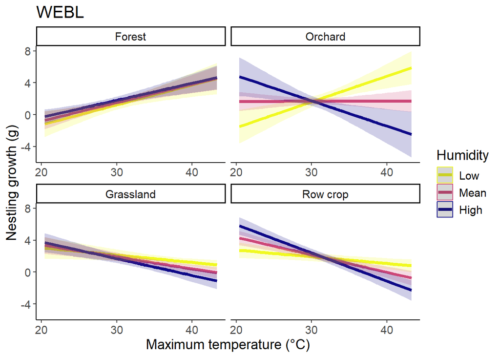

## TRES

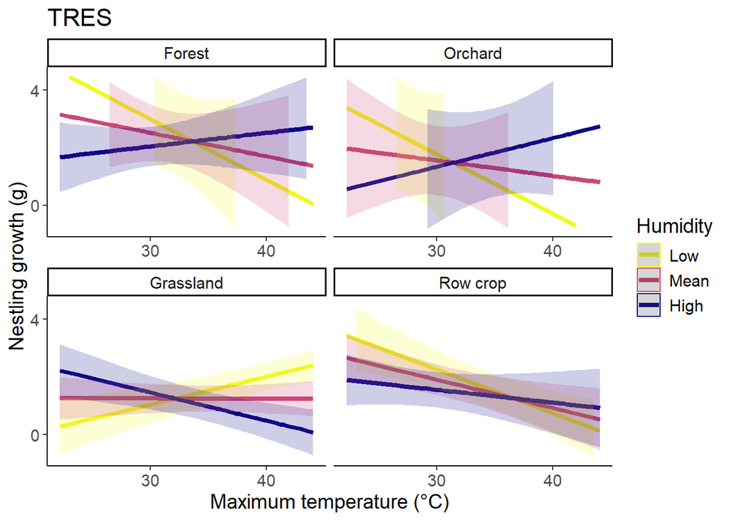

## WEBL

```r
s1bytemphabitat_WEBL_poly <- lmerTest::lmer(log(cort_s1) ~ poly(meanmaxtempI_scaled,2) * habitat + poly(meanmintempI_scaled,2) * habitat + habitat * meanh_scaled + brood_size + age_scaled + juliandate_scaled + (1|year) + (1|site/attempt_id),
                                       data = (filter(g,Species == "WEBL",
                                                     # !is.nan(cort_s1),
                                                     !is.na(meanmaxtempI),
                                                     !is.na(cort_s1)) %>%
                                    mutate(across(c(cort_s1,
                                                    meanmaxtempI,
                                                    meanmintempI,
                                                    meanh,
                                                    cort_s1_mother,
                                                    age,
                                                    juliandate),
                                                  ~ scale(.x)[,1],
                                                  .names = "{.col}_scaled"),
                                           meanmaxtempI_scaled_sq =
                                             meanmaxtempI_scaled * meanmaxtempI_scaled)))

s1bytemphabitat_WEBL_add <- lmerTest::lmer(log(cort_s1) ~ poly(meanmaxtempI_scaled,2) + poly(meanmintempI_scaled,2) * habitat + habitat * meanh_scaled + brood_size + age_scaled + juliandate_scaled + (1|year) + (1|site/attempt_id),
                                       data = (filter(g,Species == "WEBL",
                                                     # !is.nan(cort_s1),
                                                     !is.na(meanmaxtempI),
                                                     !is.na(cort_s1)) %>%
                                    mutate(across(c(cort_s1,
                                                    meanmaxtempI,
                                                    meanmintempI,
                                                    meanh,
                                                    cort_s1_mother,
                                                    age,
                                                    juliandate),
                                                  ~ scale(.x)[,1],
                                                  .names = "{.col}_scaled"),
                                           meanmaxtempI_scaled_sq =
                                             meanmaxtempI_scaled * meanmaxtempI_scaled)))

s1bytemphabitat_WEBL_notemp <- lmerTest::lmer(log(cort_s1) ~ poly(meanmintempI_scaled,2) * habitat + habitat * meanh_scaled + brood_size + age_scaled + juliandate_scaled + (1|year) + (1|site/attempt_id),
                                       data = (filter(g,Species == "WEBL",
                                                     # !is.nan(cort_s1),
                                                     !is.na(meanmaxtempI),
                                                     !is.na(cort_s1)) %>%
                                    mutate(across(c(cort_s1,
                                                    meanmaxtempI,
                                                    meanmintempI,
                                                    meanh,
                                                    cort_s1_mother,
                                                    age,
                                                    juliandate),
                                                  ~ scale(.x)[,1],
                                                  .names = "{.col}_scaled"),
                                           meanmaxtempI_scaled_sq =
                                             meanmaxtempI_scaled * meanmaxtempI_scaled)))

s1bytemphabitat_WEBL_tempnohab <- lmerTest::lmer(log(cort_s1) ~ poly(meanmaxtempI_scaled,2) + poly(meanmintempI_scaled,2) + meanh_scaled + brood_size + age_scaled + juliandate_scaled + (1|year) + (1|site/attempt_id),
                                       data = (filter(g,Species == "WEBL",
                                                     # !is.nan(cort_s1),
                                                     !is.na(meanmaxtempI),
                                                     !is.na(cort_s1)) %>%
                                    mutate(across(c(cort_s1,
                                                    meanmaxtempI,
                                                    meanmintempI,
                                                    meanh,
                                                    cort_s1_mother,
                                                    age,
                                                    juliandate),
                                                  ~ scale(.x)[,1],
                                                  .names = "{.col}_scaled"),
                                           meanmaxtempI_scaled_sq =
                                             meanmaxtempI_scaled * meanmaxtempI_scaled)))

anova(s1bytemphabitat_WEBL_tempnohab,s1bytemphabitat_WEBL_poly,s1bytemphabitat_WEBL_add,s1bytemphabitat_WEBL_notemp)
```

|  | npar | AIC | BIC | logLik | deviance | Chisq | Df | Pr(>Chisq) |
| --- | --- | --- | --- | --- | --- | --- | --- | --- |
| s1bytemphabitat_WEBL_tempnohab | 13 | 199.0351 | 234.9434 | -86.51757 | 173.0351 | NA | NA | NA |
| s1bytemphabitat_WEBL_notemp | 23 | 202.3336 | 265.8636 | -78.16680 | 156.3336 | 16.7015270 | 10 | 0.08123488 |
| s1bytemphabitat_WEBL_add | 25 | 205.5318 | 274.5861 | -77.76590 | 155.5318 | 0.8018121 | 2 | 0.66971299 |
| s1bytemphabitat_WEBL_poly | 31 | 210.5227 | 296.1501 | -74.26135 | 148.5227 | 7.0090946 | 6 | 0.32000696 |

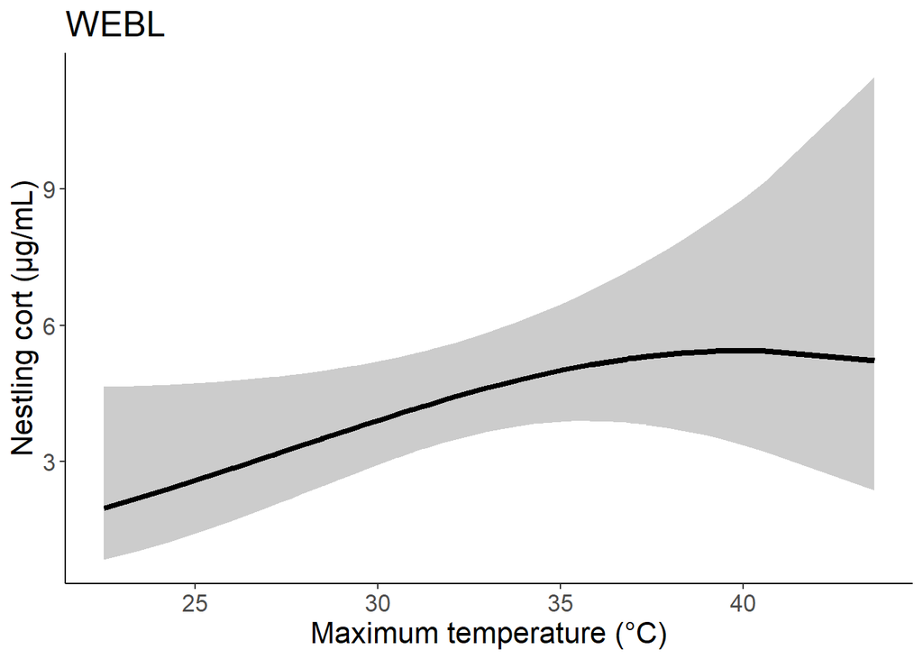

```r
s1byhabitat_WEBL_poly <- lmerTest::lmer(log(cort_s1) ~ poly(meanmintempI_scaled,2) * habitat + habitat * meanh_scaled + brood_size + age_scaled + juliandate_scaled + (1|year) + (1|site/attempt_id),
                                       data = (filter(g,Species == "WEBL",
                                                     # !is.nan(cort_s1),
                                                     !is.na(meanmaxtempI),
                                                     !is.na(cort_s1)) %>%
                                    mutate(across(c(cort_s1,
                                                    meanmaxtempI,
                                                    meanmintempI,
                                                    meanh,
                                                    cort_s1_mother,
                                                    age,
                                                    juliandate),
                                                  ~ scale(.x)[,1],
                                                  .names = "{.col}_scaled"),
                                           meanmaxtempI_scaled_sq =
                                             meanmaxtempI_scaled * meanmaxtempI_scaled)))

s1byhabitat_WEBL_poly_lmer <- lme4::lmer(log(cort_s1) ~ poly(meanmintempI_scaled,2) * habitat + habitat * meanh_scaled + brood_size + age_scaled + juliandate_scaled + (1|year) + (1|site/attempt_id),
                                       data = (filter(g,Species == "WEBL",
                                                     # !is.nan(cort_s1),
                                                     !is.na(meanmaxtempI),
                                                     !is.na(cort_s1)) %>%
                                    mutate(across(c(cort_s1,
                                                    meanmaxtempI,
                                                    meanmintempI,
                                                    meanh,
                                                    cort_s1_mother,
                                                    age,
                                                    juliandate),
                                                  ~ scale(.x)[,1],
                                                  .names = "{.col}_scaled"),
                                           meanmaxtempI_scaled_sq =
                                             meanmaxtempI_scaled * meanmaxtempI_scaled)))

summary(s1byhabitat_WEBL_poly)
```

```
## Linear mixed model fit by REML. t-tests use Satterthwaite's method [
## lmerModLmerTest]
## Formula: log(cort_s1) ~ poly(meanmintempI_scaled, 2) * habitat + habitat *
##     meanh_scaled + brood_size + age_scaled + juliandate_scaled +
##     (1 | year) + (1 | site/attempt_id)
##    Data:
## (filter(g, Species == "WEBL", !is.na(meanmaxtempI), !is.na(cort_s1)) %>%
##     mutate(across(c(cort_s1, meanmaxtempI, meanmintempI, meanh,
##         cort_s1_mother, age, juliandate), ~scale(.x)[, 1], .names = "{.col}_scaled"),
##         meanmaxtempI_scaled_sq = meanmaxtempI_scaled * meanmaxtempI_scaled))
##
## REML criterion at convergence: 152.7
##
## Scaled residuals:
##     Min      1Q  Median      3Q     Max
## -4.8067 -0.3874  0.0270  0.4816  2.2287
##
## Random effects:
##  Groups          Name        Variance  Std.Dev.
##  attempt_id:site (Intercept) 2.040e-01 0.4516347
##  site            (Intercept) 0.000e+00 0.0000000
##  year            (Intercept) 6.337e-08 0.0002517
##  Residual                    1.753e-01 0.4187373
## Number of obs: 117, groups:  attempt_id:site, 35; site, 4; year, 2
##
## Fixed effects:
##                                                Estimate Std. Error       df
## (Intercept)                                     2.08293    0.68097 19.87498
## poly(meanmintempI_scaled, 2)1                   5.41455    3.25930 29.12806
## poly(meanmintempI_scaled, 2)2                   1.47043    2.18766 40.11737
## habitatOrchard                                  0.08769    0.29427 19.21943
## habitatGrassland                                0.63758    0.36965 37.00200
## habitatRow crop                                 0.19730    0.25027 15.56408
## meanh_scaled                                   -0.31587    0.18300 19.90299
## brood_size                                     -0.14928    0.14756 20.05749
## age_scaled                                      0.10295    0.06127 97.05418
## juliandate_scaled                              -0.54916    0.16093 22.44205
## poly(meanmintempI_scaled, 2)1:habitatOrchard    0.42181    4.19071 25.66141
## poly(meanmintempI_scaled, 2)2:habitatOrchard   -0.72554    3.79245 32.54692
## poly(meanmintempI_scaled, 2)1:habitatGrassland  0.55915    4.77074 78.01487
```

[output cut: 15 more lines]

```
## age_scaled                                       1.680  0.09609 .
## juliandate_scaled                               -3.412  0.00245 **
## poly(meanmintempI_scaled, 2)1:habitatOrchard     0.101  0.92061
## poly(meanmintempI_scaled, 2)2:habitatOrchard    -0.191  0.84947
## poly(meanmintempI_scaled, 2)1:habitatGrassland   0.117  0.90700
## poly(meanmintempI_scaled, 2)2:habitatGrassland   0.273  0.78557
## poly(meanmintempI_scaled, 2)1:habitatRow crop   -0.598  0.55481
## poly(meanmintempI_scaled, 2)2:habitatRow crop   -0.281  0.78082
## habitatOrchard:meanh_scaled                      2.167  0.04056 *
## habitatGrassland:meanh_scaled                    1.885  0.07017 .
## habitatRow crop:meanh_scaled                     2.376  0.02413 *
## ---
## Signif. codes:  0 '***' 0.001 '**' 0.01 '*' 0.05 '.' 0.1 ' ' 1
## optimizer (nloptwrap) convergence code: 0 (OK)
## boundary (singular) fit: see help('isSingular')
```

```r
s1byhabtemp_WEBL_poly <- lmerTest::lmer(log(cort_s1) ~ habitat * meanmaxtempI_scaled + poly(meanmintempI_scaled,2) * habitat + meanh_scaled * habitat + brood_size + age_scaled + juliandate_scaled + (1|year) + (1|site/attempt_id),
                                       data = (filter(g,Species == "WEBL",
                                                     # !is.nan(cort_s1),
                                                     !is.na(meanmaxtempI),
                                                     !is.na(cort_s1)) %>%
                                    mutate(across(c(cort_s1,
                                                    meanmaxtempI,
                                                    meanmintempI,
                                                    meanh,
                                                    cort_s1_mother,
                                                    age,
                                                    juliandate),
                                                  ~ scale(.x)[,1],
                                                  .names = "{.col}_scaled"),
                                           meanmaxtempI_scaled_sq =
                                             meanmaxtempI_scaled * meanmaxtempI_scaled)))

s1byhabnotemp_WEBL_poly <- lmerTest::lmer(log(cort_s1) ~ meanmaxtempI_scaled + poly(meanmintempI_scaled,2) * habitat + meanh_scaled * habitat + brood_size + age_scaled + juliandate_scaled + (1|year) + (1|site/attempt_id),
                                       data = (filter(g,Species == "WEBL",
                                                     # !is.nan(cort_s1),
                                                     !is.na(meanmaxtempI),
                                                     !is.na(cort_s1)) %>%
                                    mutate(across(c(cort_s1,
                                                    meanmaxtempI,
                                                    meanmintempI,
                                                    meanh,
                                                    cort_s1_mother,
                                                    age,
                                                    juliandate),
                                                  ~ scale(.x)[,1],
                                                  .names = "{.col}_scaled"),
                                           meanmaxtempI_scaled_sq =
                                             meanmaxtempI_scaled * meanmaxtempI_scaled)))

anova(s1byhabtemp_WEBL_poly,s1byhabnotemp_WEBL_poly,s1byhabitat_WEBL_poly)
```

|  | npar | AIC | BIC | logLik | deviance | Chisq | Df | Pr(>Chisq) |
| --- | --- | --- | --- | --- | --- | --- | --- | --- |
| s1byhabitat_WEBL_poly | 23 | 202.3336 | 265.8636 | -78.16680 | 156.3336 | NA | NA | NA |
| s1byhabnotemp_WEBL_poly | 24 | 203.6585 | 269.9507 | -77.82927 | 155.6585 | 0.6750718 | 1 | 0.4112889 |
| s1byhabtemp_WEBL_poly | 27 | 208.9184 | 283.4971 | -77.45921 | 154.9184 | 0.7401100 | 3 | 0.8637315 |

[figure not shown]

```
##
##   Simultaneous Tests for General Linear Hypotheses
##
## Multiple Comparisons of Means: Tukey Contrasts
##
##
## Fit: lme4::lmer(formula = log(cort_s1) ~ poly(meanmintempI_scaled,
##     2) * habitat + habitat * meanh_scaled + brood_size + age_scaled +
##     juliandate_scaled + (1 | year) + (1 | site/attempt_id), data = (filter(g,
##     Species == "WEBL", !is.na(meanmaxtempI), !is.na(cort_s1)) %>%
##     mutate(across(c(cort_s1, meanmaxtempI, meanmintempI, meanh,
##         cort_s1_mother, age, juliandate), ~scale(.x)[, 1], .names = "{.col}_scaled"),
##         meanmaxtempI_scaled_sq = meanmaxtempI_scaled * meanmaxtempI_scaled)))
##
## Linear Hypotheses:
##                           Estimate Std. Error z value Pr(>|z|)
## Orchard - Forest == 0      0.08769    0.29427   0.298    0.991
## Grassland - Forest == 0    0.63758    0.36965   1.725    0.305
## Row crop - Forest == 0     0.19730    0.25027   0.788    0.857
## Grassland - Orchard == 0   0.54989    0.39376   1.397    0.495
## Row crop - Orchard == 0    0.10961    0.28776   0.381    0.981
## Row crop - Grassland == 0 -0.44028    0.36084  -1.220    0.608
## (Adjusted p values reported -- single-step method)
```

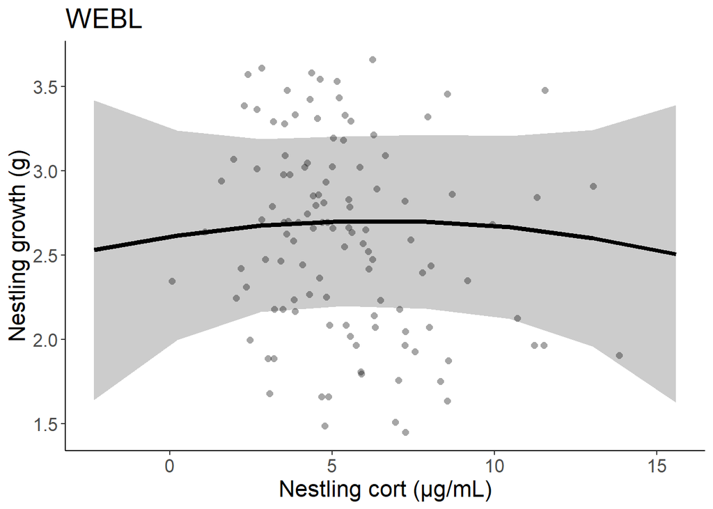

## TRES

```r
s1byhabitat_TRES_poly <- lmerTest::lmer(log(cort_s1) ~ poly(meanmintempI_scaled,2) * habitat + habitat * meanh_scaled + brood_size + age_scaled + juliandate_scaled + (1|year) + (1|site/attempt_id),
                                       data = (filter(g,Species == "TRES",
                                                     # !is.nan(cort_s1),
                                                     !is.na(meanmaxtempI),
                                                     !is.na(cort_s1)) %>%
                                    mutate(across(c(cort_s1,
                                                    meanmaxtempI,
                                                    meanmintempI,
                                                    meanh,
                                                    cort_s1_mother,
                                                    age,
                                                    juliandate),
                                                  ~ scale(.x)[,1],
                                                  .names = "{.col}_scaled"),
                                           meanmaxtempI_scaled_sq =
                                             meanmaxtempI_scaled * meanmaxtempI_scaled)))

s1byhabitat_TRES_poly_lmer <- lme4::lmer(log(cort_s1) ~ poly(meanmintempI_scaled,2) * habitat + habitat * meanh_scaled + brood_size + age_scaled + juliandate_scaled + (1|year) + (1|site/attempt_id),
                                       data = (filter(g,Species == "TRES",
                                                     # !is.nan(cort_s1),
                                                     !is.na(meanmaxtempI),
                                                     !is.na(cort_s1)) %>%
                                    mutate(across(c(cort_s1,
                                                    meanmaxtempI,
                                                    meanmintempI,
                                                    meanh,
                                                    cort_s1_mother,
                                                    age,
                                                    juliandate),
                                                  ~ scale(.x)[,1],
                                                  .names = "{.col}_scaled"),
                                           meanmaxtempI_scaled_sq =
                                             meanmaxtempI_scaled * meanmaxtempI_scaled)))

summary(s1byhabitat_TRES_poly)
```

```
## Linear mixed model fit by REML. t-tests use Satterthwaite's method [
## lmerModLmerTest]
## Formula: log(cort_s1) ~ poly(meanmintempI_scaled, 2) * habitat + habitat *
##     meanh_scaled + brood_size + age_scaled + juliandate_scaled +
##     (1 | year) + (1 | site/attempt_id)
##    Data:
## (filter(g, Species == "TRES", !is.na(meanmaxtempI), !is.na(cort_s1)) %>%
##     mutate(across(c(cort_s1, meanmaxtempI, meanmintempI, meanh,
##         cort_s1_mother, age, juliandate), ~scale(.x)[, 1], .names = "{.col}_scaled"),
##         meanmaxtempI_scaled_sq = meanmaxtempI_scaled * meanmaxtempI_scaled))
##
## REML criterion at convergence: 88.9
##
## Scaled residuals:
##      Min       1Q   Median       3Q      Max
## -2.38563 -0.57520 -0.00999  0.64646  1.71954
##
## Random effects:
##  Groups          Name        Variance Std.Dev.
##  attempt_id:site (Intercept) 0.0000   0.0000
##  site            (Intercept) 0.0135   0.1162
##  year            (Intercept) 0.1266   0.3558
##  Residual                    0.1811   0.4255
## Number of obs: 93, groups:  attempt_id:site, 36; site, 4; year, 2
##
## Fixed effects:
##                                                  Estimate Std. Error         df
## (Intercept)                                      1.214511   0.533129  12.561647
## poly(meanmintempI_scaled, 2)1                   -9.076433   4.898804  73.505513
## poly(meanmintempI_scaled, 2)2                    9.465572   8.459606  71.231112
## habitatOrchard                                  -1.137322   0.674829  42.192307
## habitatGrassland                                -0.424069   0.334573  71.863581
## habitatRow crop                                  0.568194   0.839434  71.739671
## meanh_scaled                                     0.002842   0.603012  72.535804
## brood_size                                       0.181105   0.068720  70.203764
## age_scaled                                       0.142101   0.061525  73.005546
## juliandate_scaled                                0.229172   0.090580  62.759900
## poly(meanmintempI_scaled, 2)1:habitatOrchard    23.245420  10.647301  73.198151
## poly(meanmintempI_scaled, 2)2:habitatOrchard   -24.853049  12.473624  73.431002
## poly(meanmintempI_scaled, 2)1:habitatGrassland   6.229503   4.694644  72.314820
```

[output cut: 15 more lines]

```
## age_scaled                                       2.310   0.0237 *
## juliandate_scaled                                2.530   0.0139 *
## poly(meanmintempI_scaled, 2)1:habitatOrchard     2.183   0.0322 *
## poly(meanmintempI_scaled, 2)2:habitatOrchard    -1.992   0.0500 .
## poly(meanmintempI_scaled, 2)1:habitatGrassland   1.327   0.1887
## poly(meanmintempI_scaled, 2)2:habitatGrassland  -1.100   0.2750
## poly(meanmintempI_scaled, 2)1:habitatRow crop   -0.581   0.5631
## poly(meanmintempI_scaled, 2)2:habitatRow crop   -0.016   0.9875
## habitatOrchard:meanh_scaled                      0.549   0.5871
## habitatGrassland:meanh_scaled                   -0.483   0.6304
## habitatRow crop:meanh_scaled                    -0.092   0.9267
## ---
## Signif. codes:  0 '***' 0.001 '**' 0.01 '*' 0.05 '.' 0.1 ' ' 1
## optimizer (nloptwrap) convergence code: 0 (OK)
## boundary (singular) fit: see help('isSingular')
```

```r
s1byhabtemp_TRES_poly <- lmerTest::lmer(log(cort_s1) ~ habitat * meanmaxtempI_scaled + poly(meanmintempI_scaled,2) * habitat + meanh_scaled * habitat + brood_size + age_scaled + juliandate_scaled + (1|year) + (1|site/attempt_id),
                                       data = (filter(g,Species == "TRES",
                                                     # !is.nan(cort_s1),
                                                     !is.na(meanmaxtempI),
                                                     !is.na(cort_s1)) %>%
                                    mutate(across(c(cort_s1,
                                                    meanmaxtempI,
                                                    meanmintempI,
                                                    meanh,
                                                    cort_s1_mother,
                                                    age,
                                                    juliandate),
                                                  ~ scale(.x)[,1],
                                                  .names = "{.col}_scaled"),
                                           meanmaxtempI_scaled_sq =
                                             meanmaxtempI_scaled * meanmaxtempI_scaled)))

s1byhabnotemp_TRES_poly <- lmerTest::lmer(log(cort_s1) ~ meanmaxtempI_scaled + poly(meanmintempI_scaled,2) * habitat + meanh_scaled * habitat + brood_size + age_scaled + juliandate_scaled + (1|year) + (1|site/attempt_id),
                                       data = (filter(g,Species == "TRES",
                                                     # !is.nan(cort_s1),
                                                     !is.na(meanmaxtempI),
                                                     !is.na(cort_s1)) %>%
                                    mutate(across(c(cort_s1,
                                                    meanmaxtempI,
                                                    meanmintempI,
                                                    meanh,
                                                    cort_s1_mother,
                                                    age,
                                                    juliandate),
                                                  ~ scale(.x)[,1],
                                                  .names = "{.col}_scaled"),
                                           meanmaxtempI_scaled_sq =
                                             meanmaxtempI_scaled * meanmaxtempI_scaled)))

anova(s1byhabtemp_TRES_poly,s1byhabnotemp_TRES_poly,s1byhabitat_TRES_poly)
```

|  | npar | AIC | BIC | logLik | deviance | Chisq | Df | Pr(>Chisq) |
| --- | --- | --- | --- | --- | --- | --- | --- | --- |
| s1byhabitat_TRES_poly | 23 | 138.0654 | 196.3152 | -46.03269 | 92.06538 | NA | NA | NA |
| s1byhabnotemp_TRES_poly | 24 | 139.5447 | 200.3271 | -45.77234 | 91.54468 | 0.5206992 | 1 | 0.4705436 |
| s1byhabtemp_TRES_poly | 27 | 141.4382 | 209.8184 | -43.71911 | 87.43821 | 4.1064660 | 3 | 0.2501949 |

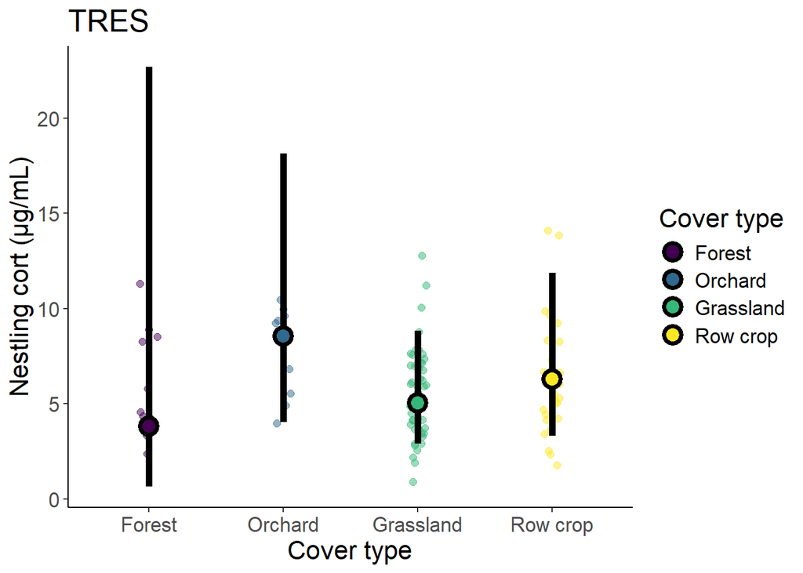

```
##
##   Simultaneous Tests for General Linear Hypotheses
##
## Multiple Comparisons of Means: Tukey Contrasts
##
##
## Fit: lme4::lmer(formula = log(cort_s1) ~ poly(meanmintempI_scaled,
##     2) * habitat + habitat * meanh_scaled + brood_size + age_scaled +
##     juliandate_scaled + (1 | year) + (1 | site/attempt_id), data = (filter(g,
##     Species == "TRES", !is.na(meanmaxtempI), !is.na(cort_s1)) %>%
##     mutate(across(c(cort_s1, meanmaxtempI, meanmintempI, meanh,
##         cort_s1_mother, age, juliandate), ~scale(.x)[, 1], .names = "{.col}_scaled"),
##         meanmaxtempI_scaled_sq = meanmaxtempI_scaled * meanmaxtempI_scaled)))
##
## Linear Hypotheses:
##                           Estimate Std. Error z value Pr(>|z|)
## Orchard - Forest == 0      -1.1373     0.6748  -1.685    0.304
## Grassland - Forest == 0    -0.4241     0.3346  -1.267    0.554
## Row crop - Forest == 0      0.5682     0.8394   0.677    0.895
## Grassland - Orchard == 0    0.7133     0.6163   1.157    0.626
## Row crop - Orchard == 0     1.7055     1.0004   1.705    0.294
## Row crop - Grassland == 0   0.9923     0.7786   1.274    0.550
## (Adjusted p values reported -- single-step method)
```